# Part II - Ford Go Bike System Usage Pattern Feb'19

## by Matthew Chan

## Investigation Overview

> A regional bike-sharing program called Ford GoBike operates in the Californian San Francisco Bay Area. With approximately 500,000 rides since its debut in 2017, Ford GoBike is the first regional and extensive bicycle sharing system set up in California and along the West Coast of the United States. As of January 2018, it has about 10,000 annual subscribers. The primary goal of this investigation and visualization project is to identify consumer habits and bike usage patterns using data from one month's worth of riding trips in February of 2019.

## Dataset Overview

> The dataset presents a daily view of individual users trip data in February 2019. The information was stored in a comma-separated values file (csv) and contains 183,412 rows of datapoints.

|  | data_type | non-null-rows | unique_rows | missing_rows |
| --- | --- | --- | --- | --- |
| duration_sec | int64 | 175147 | 4432 | 0 |
| start_time | datetime64[ns] | 175147 | 175136 | 0 |
| end_time | datetime64[ns] | 175147 | 175134 | 0 |
| start_station_id | object | 175147 | 330 | 0 |
| start_station_name | object | 174952 | 329 | 195 |
| start_station_latitude | float64 | 175147 | 334 | 0 |
| start_station_longitude | float64 | 175147 | 335 | 0 |
| end_station_id | object | 175147 | 330 | 0 |
| end_station_name | object | 174952 | 329 | 195 |
| end_station_latitude | float64 | 175147 | 335 | 0 |
| end_station_longitude | float64 | 175147 | 335 | 0 |
| bike_id | object | 175147 | 4635 | 0 |
| user_type | category | 175147 | 2 | 0 |
| member_birth_year | float64 | 175147 | 75 | 0 |
| member_gender | category | 175147 | 3 | 0 |
| bike_share_for_all_trip | object | 175147 | 2 | 0 |
| age | int32 | 175147 | 75 | 0 |
| start_date | object | 175147 | 28 | 0 |
| start_hour | object | 175147 | 24 | 0 |
| start_day | object | 175147 | 7 | 0 |
| start_month | object | 175147 | 1 | 0 |

## User Types and their Daily Usage by Day

> Subscribers contribute to a significant majority of bike trips in February 2019 of around 90.5%, while the other 9.5% was made up of customers. Both subscribers and customers typically had a peak usage period on Thursday and dipped in usage for the weekends (Saturday and Sunday).

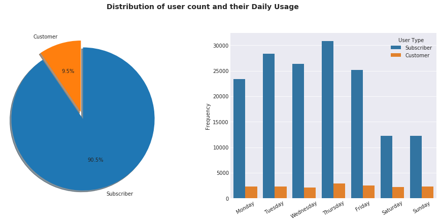